## CONCLUSION

[figure not shown]

After an extensive application of a **classical logistic model**, which we strengthened with quadratic effects and cross-tabulations, we were faced with a major problem in the context of linear regression: **multicollinearity**. Therefore, **penalized regression models** were a solution to overcome this problem, by selecting (or not) variables on our whole dataset. Four models have been developed, namely the **Ridge**, the **Lasso**, the **Adaptive Lasso** and the **Elastic Net**. These penalized regressions have the main advantage of simplicity of interpretation of the results but also of implementation of the algorithms.

We then introduced classification tree models, starting with the **CART algorithm**, which is simple to implement and interpret. Nevertheless, a tree built under this algorithm is subject to a **high risk of overfitting**. It is to this extent that **tree pruning methods** allow to reinforce the results, by proposing a **less complex tree but just as rich in generalization power**.

**Aggregation methods** are a method for **building strong learners by mobilizing weak learners**. To this extent, the first algorithms we presented were **Bagging** and **Random Forest**, **parallel aggregation methods for enhancing predictive quality by bootstrapping examples into a set consisting of the most complex tree**. The generalization power obtained by our model **increases with the number of bootstrapped samples within our sample**. We are therefore faced with a dilemma between performance and computer time.

And then the **Boosting**, a **sequential aggregation method where the reinforcement of the learning is established by assigning higher weights to the misclassified individuals during the previous iteration**. In this respect, two main algorithms were presented, namely **Adaboost** and **Gradient Boosting**. Their main advantage over Random Forest is the computation time, even if more hyperparameters have to be determined.

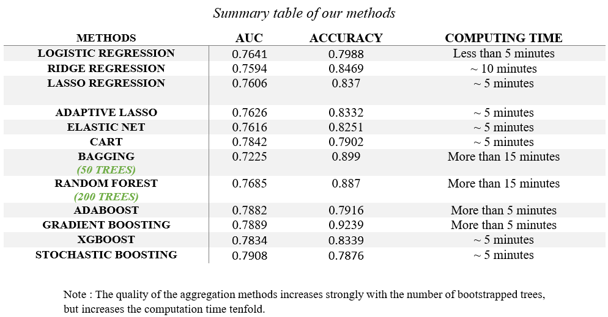